# 6_LDA Speech

# Introduction

- Using dataset https://data.gov.tw/dataset/42540

## Process-of

1. Getting word tokens by `doc_term_count <- unnest()`
2. Building DocumentTermMatrix by `dtm <- tidytext::cast_dtm(doc_term_count, title, words, n)`
3. Modeling by `dtm_lda <- topicmodels::LDA(dtm, k = 16, control = list(seed = 1234))`
4. Results
   1. Visualize word-topic probability by `dtm_topics <- tidy(dtm_lda, matrix = "beta")`
   2. Getting document-topic probability
   3. Building term network
5. Evaluation
   1. Calculating perplexity by different number of topics
   2. Evaluating by `library(ldatuning)`

# Loading

```r
library(tidyverse)
library(tidyr) # for unnest()
library(stringr)
# " xcode-select --install"
# install.packages("http://download.r-forge.r-project.org/src/contrib/tmcn_0.2-9.tar.gz", repos = NULL, type = "source")
# library(tmcn)

# install.packages("devtools")
# devtools::install_github("qinwf/ropencc") # Convert S to Trad
```

# Loading data

```r
# load("data/speech_data.RData")
#
# names(data_list) <- iconv(names(data_list), from="BIG5", to="UTF8")
# data_list$標題 <- iconv(data_list$標題, from="BIG5", to="UTF8")
# data_list <- data_list[-c(1,27),]
# # data_list$content <- iconv(data_list$content, from="BIG5", to="UTF8")
# data_list$content <- toTrad(data_list$content)
# docs$word <- NULL
#
# saveRDS(docs, "data/toChinaSpeech.rds")
# names(docs) <- c("title", "date", "link", "content", "word")
docs <- readRDS("data/toChinaSpeech.rds")
# data_list$word <- iconv(data_list$word, from="BIG5", to="UTF8")

# data_list$word <- sapply(data_list$word, function(x){iconv(x, from="BIG5", to="UTF8")})
```

# Word segmentation

```r
library(jiebaR)

cutter <- worker()
segment_not <- c("蔡英文", "南向政策", "副總統")
new_user_word(cutter, segment_not)

docs <- docs %>%
    mutate(content = stringr::str_replace_all(content, "台灣", "臺灣")) %>%
    select(-link)

docs$words <- sapply(docs$content, function(x){tryCatch({cutter[x]}, error=function(err){})})
```

# Loading stopWords

```r
stopWords <- readRDS("data/stopWords.rds") %>%
    .$word %>% unlist() %>% as.character()
```

```
fin <- file("data/stopwords_tw.txt",open="r")
stopWords <- readLines(fin, encoding="UTF-8")
stopWords <- unique(stopWords)
added <- c("ㄟ")
reserved <- c("我們")
stopWords <- setdiff(stopWords, reserved)
stopWords <- union(stopWords, added)
```

# Building DocumentTermMatrix

```r
library(tidytext)
dtm <- cast_dtm(doc_term_count, title, words, n)
```

# LDA

```r
library(topicmodels)
dtm_lda <- LDA(dtm, k = 16, control = list(seed = 1234))
dtm_lda4 <- LDA(dtm, k = 4, control = list(seed = 1234))
```

# Word-topic probabilities

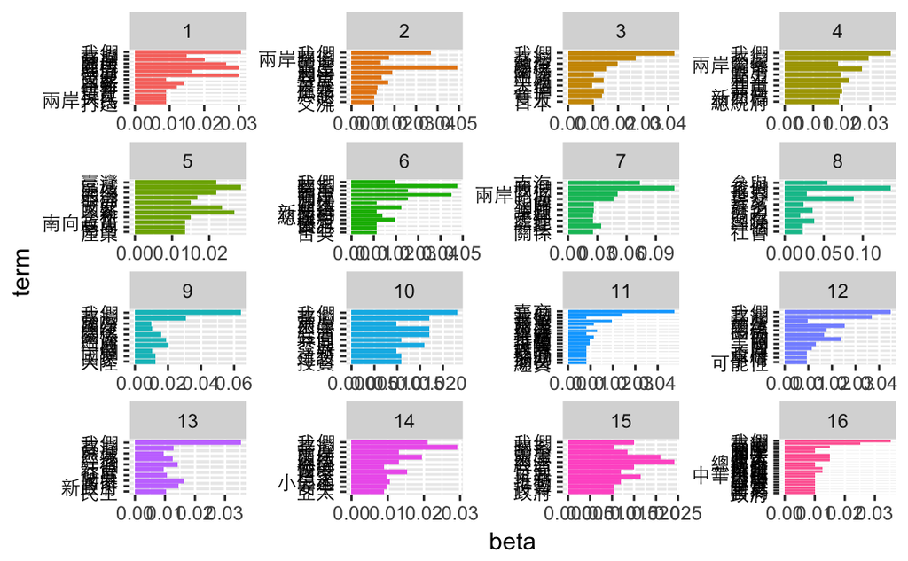

```r
library(ggplot2)
dtm_topics <- tidy(dtm_lda, matrix = "beta")
top_terms <- dtm_topics %>%
    group_by(topic) %>%
    top_n(10, beta) %>%
    ungroup() %>%
    arrange(topic, -beta)
# View(top_terms)
top_terms %>%
    mutate(term = reorder(term, beta)) %>%
    ggplot(aes(term, beta, fill = factor(topic))) +
    geom_col(show.legend = FALSE) +
    facet_wrap(~ topic, scales = "free") +
    coord_flip() +
    theme(axis.text.y=element_text(colour="black", family="Heiti TC Light"))
```

## Comparing k=4

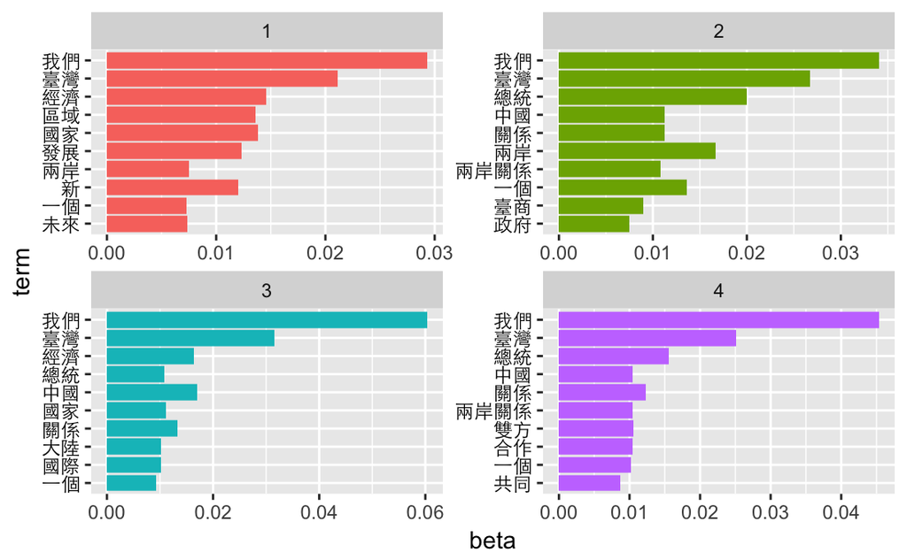

```r
dtm_topics_4 <- tidy(dtm_lda4)
top_terms_4 <- dtm_topics_4 %>%
    group_by(topic) %>%
    top_n(10, beta) %>%
    ungroup() %>%
    arrange(topic, -beta)
View(top_terms_4)
top_terms_4 %>%
    mutate(term = reorder(term, beta)) %>%
    ggplot(aes(term, beta, fill = factor(topic))) +
    geom_col(show.legend = FALSE) +
    facet_wrap(~ topic, scales = "free") +
    coord_flip() +
    theme(axis.text.y=element_text(colour="black", family="Heiti TC Light"))
```

## Evaluation

```r
perplexity(dtm_lda)
```

```
[1] 330.0133
```

```r
perplexity(dtm_lda4)
```

```
[1] 585.7803
```

```r
# [1] 348.7432
# [1] 592.8917
# Example of entroty
-(0.6*log2(0.6) + 0.4*log2(0.4))
```

```
[1] 0.9709506
```

```r
-(0.9*log2(0.9) + 0.1*log2(0.1))
```

```
[1] 0.4689956
```

```r
# [1] 0.9709506
# [1] 0.4689956
```

```r
library(tidyverse)
n_topics <- c(2, 4, 8, 12, 16, 20, 24)

perplex <- sapply(n_topics, function(k){
    lda.temp <- LDA(dtm, k =k, control = list(seed = 1109))
    perplexity(lda.temp)
})


data_frame(k=n_topics, perplex=perplex) %>%
    ggplot(aes(k, perplex)) +
    geom_point() +
    geom_line() +
    labs(title = "Evaluating LDA topic models",
         subtitle = "Optimal number of topics (smaller is better)",
         x = "Number of topics",
         y = "Perplexity")


# n_topics <- c(2, 4, 8, 14, 16, 18, 32, 64)
# dtm_lda_compare <- n_topics %>%
#   purrr::map(LDA, x = dtm, control = list(seed = 1109))
#
#
# data_frame(k = n_topics,
#          perplex = purrr::map_dbl(dtm_lda_compare, perplexity)) %>%
#   ggplot(aes(k, perplex)) +
#   geom_point() +
#   geom_line() +
#   labs(title = "Evaluating LDA topic models",
#        subtitle = "Optimal number of topics (smaller is better)",
#        x = "Number of topics",
         # y = "Perplexity")
```

[output not shown]

## Comparing topic1 and topic 2

```r
library(tidyr)
beta_spread <- dtm_topics %>%
    mutate(topic = paste0("topic", topic)) %>%
    spread(topic, beta) %>%
    select(term, topic1, topic2) %>%
    filter(topic1 > .001 | topic2 > .001) %>%
    mutate(logratio = log2(topic1 / topic2)) %>%
    arrange(desc(logratio))
beta_spread
```

| term | topic1 | topic2 | logratio |
| --- | --- | --- | --- |
| 成員 | 8.818203e-03 | 7.157997e-310 | 1020.1328540 |
| 打壓 | 2.062310e-03 | 5.722405e-309 | 1015.0376370 |
| 傷害 | 2.050844e-03 | 5.858409e-309 | 1014.9957058 |
| 北京 | 8.162806e-03 | 3.728709e-306 | 1007.6746018 |
| 路 | 6.046939e-03 | 1.043498e-93 | 301.5083057 |
| 並按 | 3.023469e-03 | 6.158707e-94 | 301.2690341 |
| 秉持 | 3.023469e-03 | 1.043243e-93 | 300.5086579 |
| 經濟模式 | 3.023469e-03 | 1.043253e-93 | 300.5086449 |
| 多元性 | 3.023469e-03 | 1.043308e-93 | 300.5085684 |
| 關聯 | 3.023469e-03 | 1.043314e-93 | 300.5085598 |

[output cut: 420 more lines]

[figure not shown]

```r
beta_spread %>%
    group_by(logratio > 0) %>%
    top_n(20, abs(logratio)) %>%
    ungroup() %>%
    mutate(term = reorder(term, logratio)) %>%
    ggplot(aes(term, logratio, fill = logratio < 0)) +
    geom_col() +
    coord_flip() +
    ylab("Topic2/Topic1 log ratio") +
    scale_fill_manual(name = "", labels = c("topic2", "topic1"),
                      values = c("red", "lightblue")) +
    theme(axis.text.y=element_text(colour="black", family="Heiti TC Light"))
```

# Document-topic probabilities

```r
doc_topics <- tidy(dtm_lda, matrix = "gamma") %>%
    spread(topic, gamma)
doc_topics
```

| document | 1 | 2 | 3 | 4 | 5 | 6 | 7 | 8 | 9 | 10 | 11 | 12 | 13 | 14 | 15 | 16 |
| --- | --- | --- | --- | --- | --- | --- | --- | --- | --- | --- | --- | --- | --- | --- | --- | --- |
| 蔡總統就職演說與兩岸經貿有關部分 | 9.994253e-01 | 3.831284e-05 | 3.831284e-05 | 3.831284e-05 | 3.831284e-05 | 3.831284e-05 | 3.831284e-05 | 3.831284e-05 | 3.831284e-05 | 3.831284e-05 | 3.831284e-05 | 3.831284e-05 | 3.831284e-05 | 3.831284e-05 | 3.831284e-05 | 3.831284e-05 |
| 慶祝記者節總統與媒體茶敘致詞：有關兩岸關係談話內容 | 1.215990e-04 | 1.215990e-04 | 1.215990e-04 | 4.227531e-01 | 1.215990e-04 | 1.215990e-04 | 5.755445e-01 | 1.215990e-04 | 1.215990e-04 | 1.215990e-04 | 1.215990e-04 | 1.215990e-04 | 1.215990e-04 | 1.215990e-04 | 1.215990e-04 | 1.215990e-04 |
| 英國《經濟學人》雜誌《The World in 2017》專刊刊登總統專文：有關兩岸關係談話內容 | 2.110476e-04 | 2.110476e-04 | 2.110476e-04 | 9.968343e-01 | 2.110476e-04 | 2.110476e-04 | 2.110476e-04 | 2.110476e-04 | 2.110476e-04 | 2.110476e-04 | 2.110476e-04 | 2.110476e-04 | 2.110476e-04 | 2.110476e-04 | 2.110476e-04 | 2.110476e-04 |
| 中華民國第14任總統蔡英文女士就職演說 | 4.462317e-06 | 4.462317e-06 | 4.462317e-06 | 4.462317e-06 | 4.462317e-06 | 4.462317e-06 | 4.462317e-06 | 6.382570e-02 | 4.462317e-06 | 4.462317e-06 | 4.462317e-06 | 4.462317e-06 | 9.361118e-01 | 4.462317e-06 | 4.462317e-06 | 4.462317e-06 |
| 總統參拜「蔡氏家廟」、視導「小三通及港區」並出席「金門中秋博狀元餅」活動 | 2.067695e-05 | 2.067695e-05 | 2.067695e-05 | 2.067695e-05 | 2.067695e-05 | 2.067695e-05 | 2.067695e-05 | 2.067695e-05 | 2.067695e-05 | 2.067695e-05 | 2.067695e-05 | 2.067695e-05 | 2.067695e-05 | 9.996898e-01 | 2.067695e-05 | 2.067695e-05 |
| 總統出席「2016大陸臺商端午節座談聯誼活動」 | 1.450566e-05 | 1.450566e-05 | 1.450566e-05 | 1.450566e-05 | 1.450566e-05 | 1.450566e-05 | 1.450566e-05 | 1.450566e-05 | 1.450566e-05 | 1.450566e-05 | 9.997824e-01 | 1.450566e-05 | 1.450566e-05 | 1.450566e-05 | 1.450566e-05 | 1.450566e-05 |
| 總統出席「2016大陸臺商秋節聯誼活動」午宴 | 1.339176e-05 | 1.339176e-05 | 1.339176e-05 | 1.339176e-05 | 1.339176e-05 | 1.339176e-05 | 1.339176e-05 | 1.339176e-05 | 1.339176e-05 | 1.339176e-05 | 1.339176e-05 | 1.339176e-05 | 1.339176e-05 | 1.339176e-05 | 9.997991e-01 | 1.339176e-05 |
| 總統出席「2016年南海爭議與亞太區域和平國際研討會」開幕式：有關兩岸關係談話內容 | 5.166674e-05 | 4.242268e-01 | 5.166674e-05 | 5.166674e-05 | 5.166674e-05 | 5.166674e-05 | 5.166674e-05 | 5.750498e-01 | 5.166674e-05 | 5.166674e-05 | 5.166674e-05 | 5.166674e-05 | 5.166674e-05 | 5.166674e-05 | 5.166674e-05 | 5.166674e-05 |
| 總統出席「2017大陸臺商春節聯誼活動」 | 1.195206e-05 | 1.195206e-05 | 1.195206e-05 | 1.195206e-05 | 1.195206e-05 | 1.195206e-05 | 1.195206e-05 | 1.195206e-05 | 1.195206e-05 | 9.998207e-01 | 1.195206e-05 | 1.195206e-05 | 1.195206e-05 | 1.195206e-05 | 1.195206e-05 | 1.195206e-05 |
| 總統出席「2017亞太安全對話」 | 1.111556e-05 | 1.111556e-05 | 1.111556e-05 | 1.111556e-05 | 1.111556e-05 | 1.111556e-05 | 1.111556e-05 | 1.111556e-05 | 1.111556e-05 | 1.111556e-05 | 1.111556e-05 | 1.111556e-05 | 1.111556e-05 | 9.998333e-01 | 1.111556e-05 | 1.111556e-05 |

[output cut: 20 more lines]

```r
tidy(dtm) %>%
    filter(document == "總統出席「2017大陸臺商春節聯誼活動」") %>%
    arrange(desc(count))
```

| document | term | count |
| --- | --- | --- |
| 總統出席「2017大陸臺商春節聯誼活動」 | 我們 | 17 |
| 總統出席「2017大陸臺商春節聯誼活動」 | 臺灣 | 14 |
| 總統出席「2017大陸臺商春節聯誼活動」 | 台商 | 14 |
| 總統出席「2017大陸臺商春節聯誼活動」 | 經濟 | 13 |
| 總統出席「2017大陸臺商春節聯誼活動」 | 發展 | 10 |
| 總統出席「2017大陸臺商春節聯誼活動」 | 投資 | 9 |
| 總統出席「2017大陸臺商春節聯誼活動」 | 新 | 8 |
| 總統出席「2017大陸臺商春節聯誼活動」 | 建設 | 8 |
| 總統出席「2017大陸臺商春節聯誼活動」 | 共同 | 7 |
| 總統出席「2017大陸臺商春節聯誼活動」 | 兩岸 | 6 |

[output cut: 432 more lines]

# Building term networks

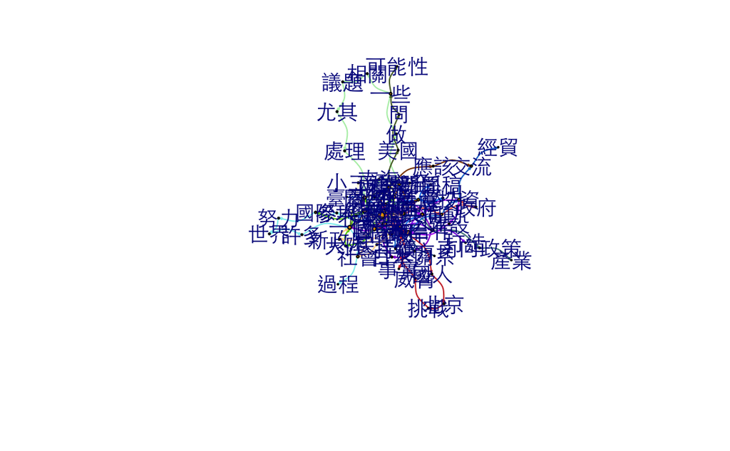

# LDAVis

- https://ldavis.cpsievert.me/reviews/reviews.html
- https://github.com/m-clark/topic-models-demo/blob/master/topic-model-demo.Rmd
- https://gist.github.com/christophergandrud/00e7451c16439421b24a
- http://christophergandrud.blogspot.tw/2015/05/a-link-between-topicmodels-lda-and.html

```r
serVis(shinyJSON)
```

[output not shown]

## The 2nd solution

- convert an lda result to json for ldavis

  ```
  topicmodels_json_ldavis <- function(fitted, corpus, doc_term){

  # Find required quantities
  phi <- posterior(fitted)$terms %>% as.matrix
  theta <- posterior(fitted)$topics %>% as.matrix
  vocab <- colnames(phi)
  doc_length <- vector()
  for (i in 1:length(corpus)) {
      temp <- paste(corpus[[i]]$content, collapse = ' ')
      doc_length <- c(doc_length, stri_count(temp, regex = '\\S+'))
  }
  temp_frequency <- inspect(doc_term)
  freq_matrix <- data.frame(ST = colnames(temp_frequency),
                            Freq = colSums(temp_frequency))
  rm(temp_frequency)

  # Convert to json
  json_lda <- LDAvis::createJSON(phi = phi, theta = theta,
                          vocab = vocab,
                          doc.length = doc_length,
                          term.frequency = freq_matrix$Freq)

  return(json_lda)
  }
  ```

# Evaluating topic number

```r
# install.packages("ldatuning")
library(ldatuning)

control_list_gibbs <- list(
    burnin = 2500,
    iter = 5000,
    seed = 0:4,
    nstart = 5,
    best = TRUE
)



system.time(
    topic_number_lemma <- FindTopicsNumber(
        dtm,
        topics = n_topics,
        metrics = c( "Griffiths2004", "CaoJuan2009", "Arun2010", "Deeaud2014"),
        method = "Gibbs",
        control = control_list_gibbs,
        mc.cores = 4L,
        verbose = TRUE
    )
)
# fit models... done.
# calculate metrics:
#   Griffiths2004... done.
#   CaoJuan2009... done.
#   Arun2010... done.
#   Deveaud2014... done.
#    user  system elapsed
#   2.138   0.459 366.005
ldatuning::FindTopicsNumber_plot(topic_number_lemma)
```

[output not shown]

## Evaluting n_topics by max gamma value of topics in each document

```r
lda.list <- lapply(n_topics, function(k){
    lda.temp <- LDA(dtm, k = k, method="Gibbs", control = list(seed = 1109))
    tidy.temp <- tidy(lda.temp, matrix="gamma")
    tidy.temp$k <- k
    tidy.temp
})
lda.df <- do.call(rbind, lda.list)

lda.df %>%
    group_by(k, document) %>%
    arrange(desc(gamma)) %>%
    slice(1) %>%
    ungroup() %>%
    ggplot(aes(x=gamma, fill=factor(k))) +
    geom_histogram(bins = 20) +
    scale_fill_discrete(name = "Number of\nTopics") +
    xlab("maximum gamma per document") +
    facet_wrap(~k)
```

[output not shown]

# Correlated Topic Modeling

- topic modeling比較適合類似新聞的文章，長度夠長，一篇文章內有多個主題，比較不適合類似社群資料等短文。而CTM（Correlated Topic Modeling）則是設計用來處理短文的主題分析。

```r
ctm.list <- lapply(n_topics, function(k){
    ctm.temp <- CTM(x=dtm, k =k, control=control_list_ctm)
    res=list(ctm=ctm.temp, k=k)
})
# lda.df <- do.call(rbind, lda.list)
```

# Acknowledgement

- This page is derived in part from “[Tidy Text Mining with R](https://www.tidytextmining.com/)” and licensed under a Creative Commons Attribution-NonCommercial-ShareAlike 3.0 United States License.
- This page is derived in part from “[What is a good explanation of Latent Dirichlet Allocation?](https://www.quora.com/What-is-a-good-explanation-of-Latent-Dirichlet-Allocation)”
- This page is dervied in part from the course “[Computing for Social Science](http://cfss.uchicago.edu/fall2016/syllabus.html)” in uChicago.
- https://chengjunwang.com/zh/post/cn/cn_archive/2013-09-27-topic-modeling-of-song-peom/
- http://www.bernhardlearns.com/2017/05/topic-models-lda-and-ctm-in-r-with.html